# Assignment-6

Ramya Sri Gautham:ramya.srigautham@rutgers.edu

11/22/2023

#### Load dataset

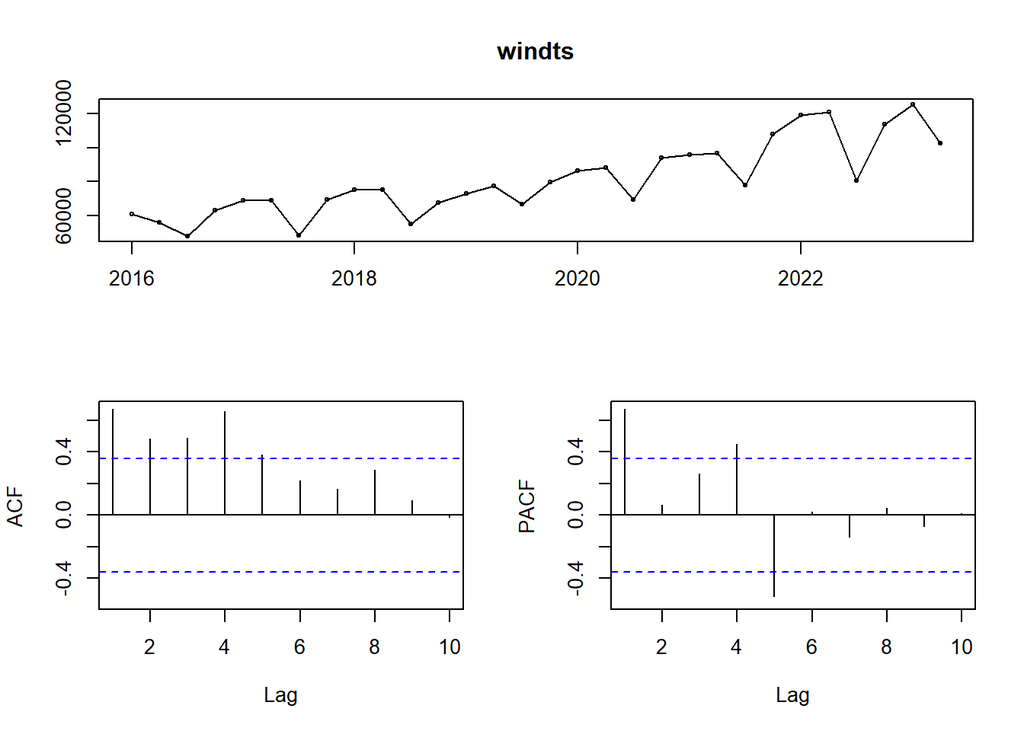

```r
#loading file and libraries
library(readxl)
library(forecast)
windDT <-read_excel("~/wind-power-production-us.xlsx")
#Time series data
ts_data <- ts(windDT$Wind_United_States, end=c(2023,2), frequency=4)
#Time series data from 2016 to 2023
windts <- window(ts_data, c(2016))
#Let's recall components present in the data set.
tsdisplay(windts)
```

* From just the above plots of the Time Series we can see that there is a upward trend in the data over the period of time and also showing signs of seasonality year to year from the regular peaks in the ACF plot.

#### Arima Output

```r
#perform auto arima on the time series data set
auto_fit <- auto.arima(windts)
auto_fit_Wostepwise <-auto.arima(windts, stepwise=FALSE, approximation=FALSE)
auto_fit
```

```
## Series: windts
## ARIMA(0,0,1)(0,1,0)[4] with drift
##
## Coefficients:
##          ma1      drift
##       0.6313  1711.2873
## s.e.  0.2446   595.8301
##
## sigma^2 = 61301205:  log likelihood = -269.21
## AIC=544.43   AICc=545.52   BIC=548.2
```

* As per the output, the **ARIMA(0,0,1)(0,1,0)[4] with drift** model is selected.  
* ARIMA(0,0,1): This is the non-seasonal part of the model:  
1. The first number (0) is the order of the AutoRegressive (AR) term. A value of 0 means that the model does not use past values of the series itself to predict future values.  
2. The second number (0) is the order of differencing (I for Integrated). Here, 0 means that the series is assumed to be stationary and does not require differencing to make it stationary.  
3.The third number (1) is the order of the Moving Average (MA) term. This indicates that the model uses one lagged forecast error in predicting future values.  
* (0,1,0)[4]: This is the seasonal component of the model:  
1. The first number in the parentheses (0) is the seasonal AR term. It’s 0, indicating no seasonal AR component.  
2. The second number (1) is the order of seasonal differencing. This means the data is seasonally differenced once to achieve stationarity.  
3.The third number (0) is the seasonal MA term, which is also 0, indicating no seasonal MA component.  
4.The number in the square brackets ([4]) represents the seasonal period (quarterly data).  
* The coefficients and their standard errors (s.e.) are given for each term. The model’s performance is indicated by the log likelihood, AIC, AICc, and BIC values.

```r
# Auto arima with stepwise=False
auto_fit_Wostepwise
```

```
## Series: windts
## ARIMA(0,0,0)(0,1,1)[4] with drift
##
## Coefficients:
##          sma1      drift
##       -0.6575  2036.6969
## s.e.   0.3731   183.5868
##
## sigma^2 = 57106093:  log likelihood = -269.17
## AIC=544.33   AICc=545.42   BIC=548.11
```

- Here, the **ARIMA(0,0,0)(0,1,1)[4] with drift** model is selected.
- non seasonal component part of the model contains 0 order of the moving Average.
- seasonal component part contains 1 moving average.
- As the AIC,BIC,accuracy is better in stepwise =False case. we will be considering this model for the prediction.

#### Residual Analysis

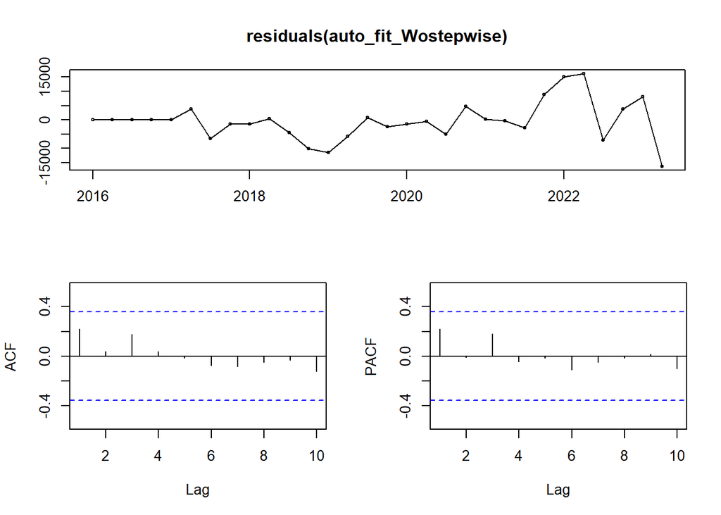

```r
#Residual Analysis
tsdisplay(residuals(auto_fit_Wostepwise))
```

* As per Acf plot there are no significant spike. Hence its only white noise.

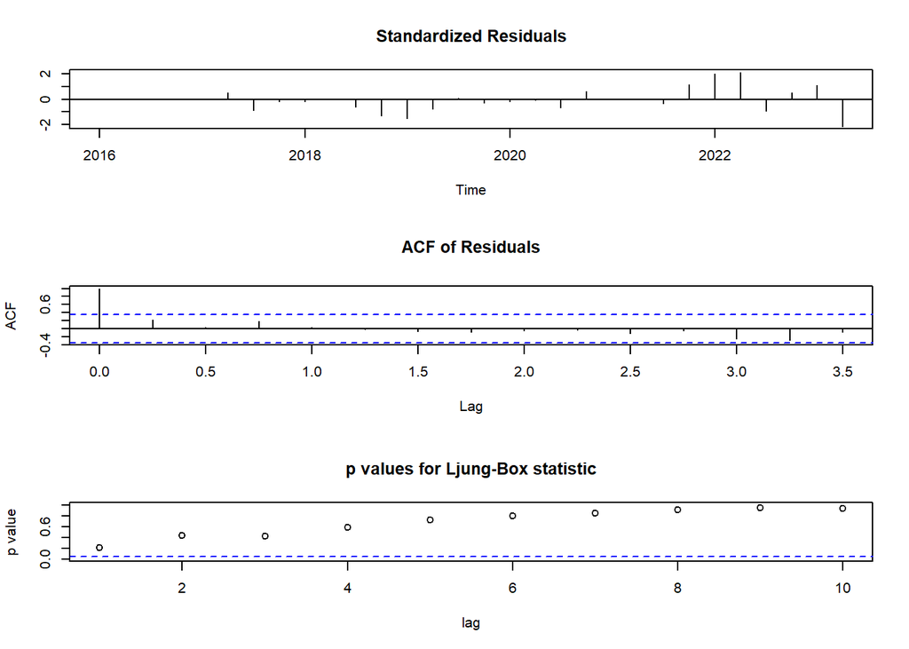

```r
tsdiag(auto_fit_Wostepwise)
```

* The Ljung-Box test is applied to the residuals and interpret the results. P-values greater than a chosen significance level indicate that the residuals do not show significant autocorrelation.

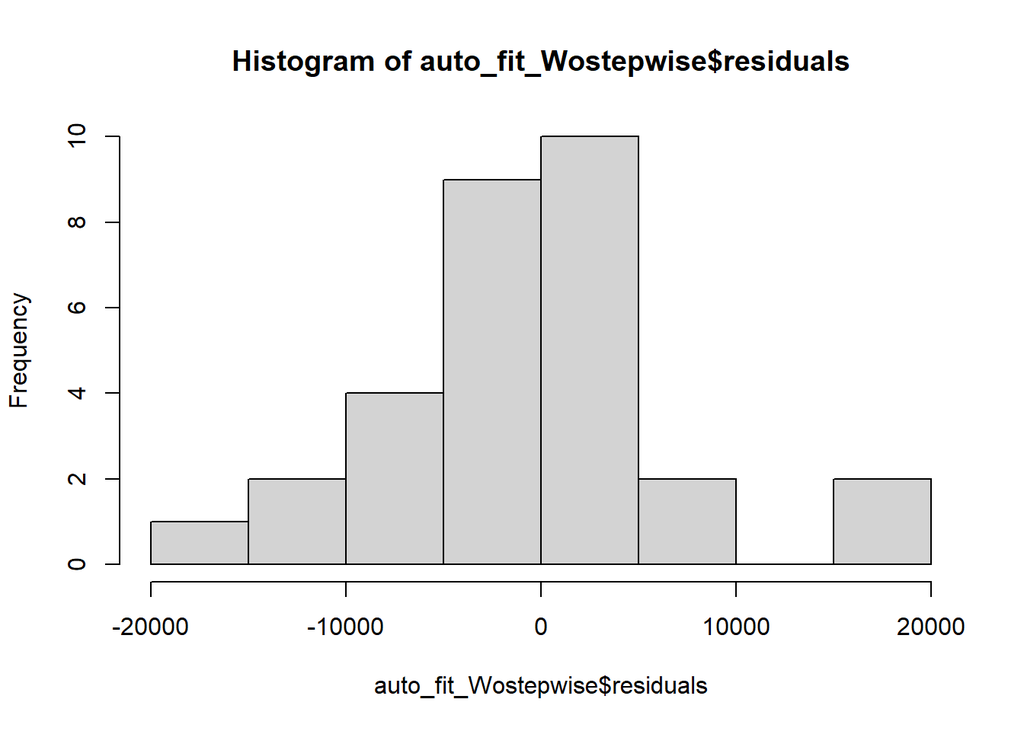

```r
hist(auto_fit_Wostepwise$residuals)
```

* As per histogram the residuals randomly distributed with a mean of zero.

#### Perform forecast

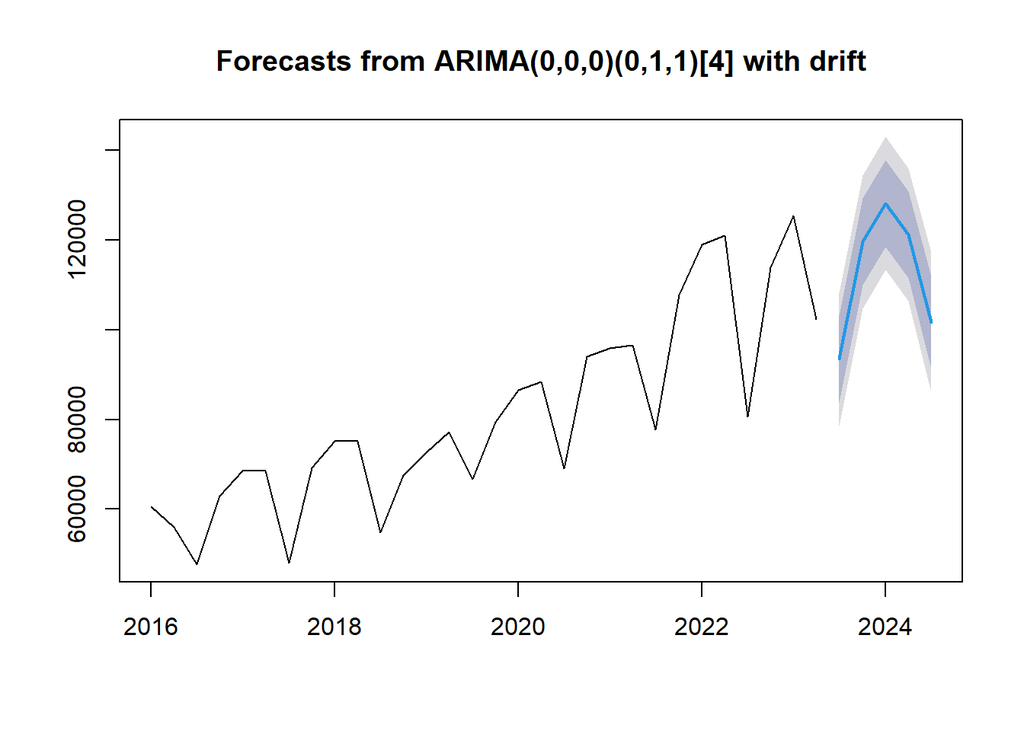

```r
#Forecast for the next 5 period
windts_for <- forecast(auto_fit_Wostepwise, h=5)
plot(windts_for)
```

* As the drift coefficient of the arima model is **2036.6969** positive , the forecast shows the linear trend in upward direction.  
* Given the seasonal MA and differencing components, the forecast account for the seasonality observed in the data, typically repeating seasonal patterns observed in the historical data every quarters.  
* 95% confidence intervals provides the range within which the future values are expected to lie.

#### Accuracy of the model

```r
# Accuracy of arima with stepwise =TRUE
accuracy(auto_fit)
```

```
##                    ME     RMSE      MAE        MPE     MAPE      MASE
## Training set 64.71987 7002.925 5073.463 -0.4551057 6.003969 0.5464625
##                     ACF1
## Training set -0.04809898
```

```r
#Accuracy of arima with stepwise =FALSE
accuracy(auto_fit_Wostepwise)
```

```
##                     ME     RMSE      MAE       MPE     MAPE      MASE      ACF1
## Training set -501.9776 6759.059 4642.815 -1.615764 5.406433 0.5000775 0.2193521
```

##### As per the accuracy RMSE of arima model **ARIMA(0,0,0)(0,1,1)[4] with drift** has **6759.059** which is better than the **ARIMA(0,0,1)(0,1,0)[4] with drift**. hence we can forecast using arima model **ARIMA(0,0,0)(0,1,1)[4] with drift**.